# Classification Models

2025-02-27

# 1. Introduction

In this report, we explore different classification models using logistic regression techniques. These models are essential tools in predicting binary and multi-class outcomes based on input features. We begin by examining binary classification using logistic regression and multiple logistic regression, followed by an exploration of multinomial logistic regression to handle cases with more than two outcome categories. The models are applied to two datasets from the ISLR2 package: **Default** and **Carseats**.

# 2. Data

We exploring the **Default dataset**, which contains credit card default information. This dataset includes variables such as **balance**, **income**, and **student status**, and **a binary variable** default indicating whether a person defaulted on their credit card debt.

```r
data = Default
str(data)
```

```
## 'data.frame':    10000 obs. of  4 variables:
##  $ default: Factor w/ 2 levels "No","Yes": 1 1 1 1 1 1 1 1 1 1 ...
##  $ student: Factor w/ 2 levels "No","Yes": 1 2 1 1 1 2 1 2 1 1 ...
##  $ balance: num  730 817 1074 529 786 ...
##  $ income : num  44362 12106 31767 35704 38463 ...
```

## 2.1 Visualizing the Data

Before building any models, we explore the data visually to detect trends, distributions, and potential relationships between variables.

### Distribution of Balance

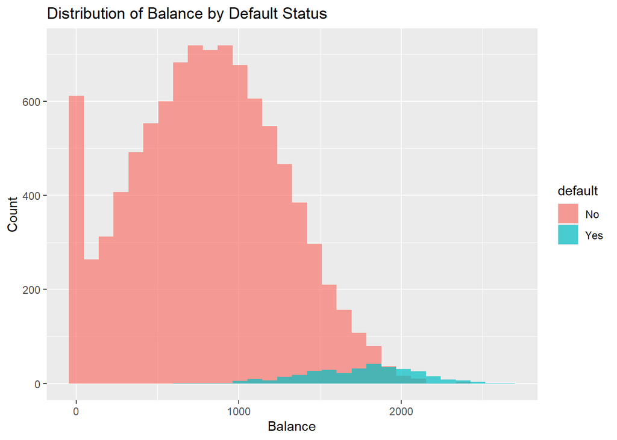

```r
ggplot(data, aes(x=balance , fill=default))+
  geom_histogram(bins = 30, alpha=0.7, position='identity')+
  labs(title = "Distribution of Balance by Default Status",
       x= "Balance",
       y= "Count")
```

This histogram shows how the distribution of credit card balances differs between those who defaulted and those who did not. A higher concentration of defaults appears at higher balance values.

### Distribution of Income

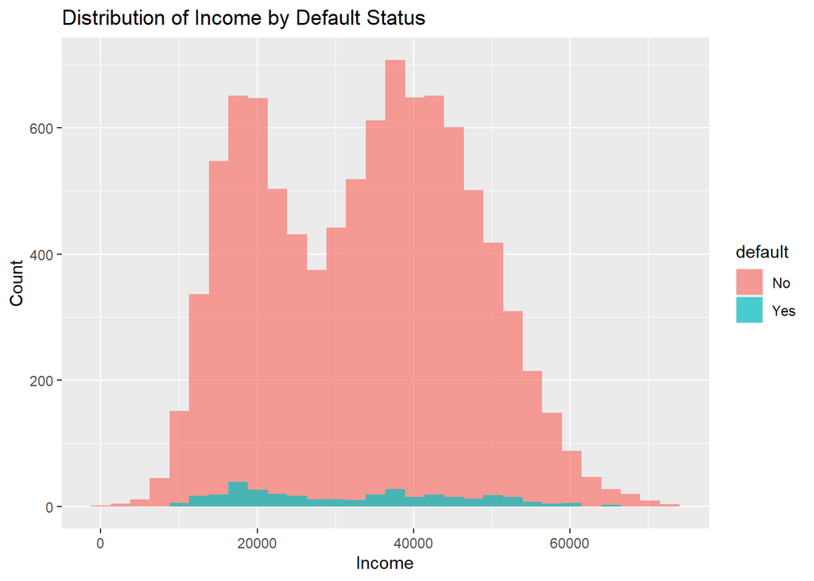

```r
ggplot(data, aes(x=income, fill = default))+
  geom_histogram(bins = 30, alpha = 0.7, position = 'identity')+
  labs(title = "Distribution of Income by Default Status",
       x= "Income",
       y= "Count")
```

This chart examines whether income is a strong indicator of default. Unlike balance, income may have a less distinct pattern in separating defaulters.

### Distribution of Income by Student Status

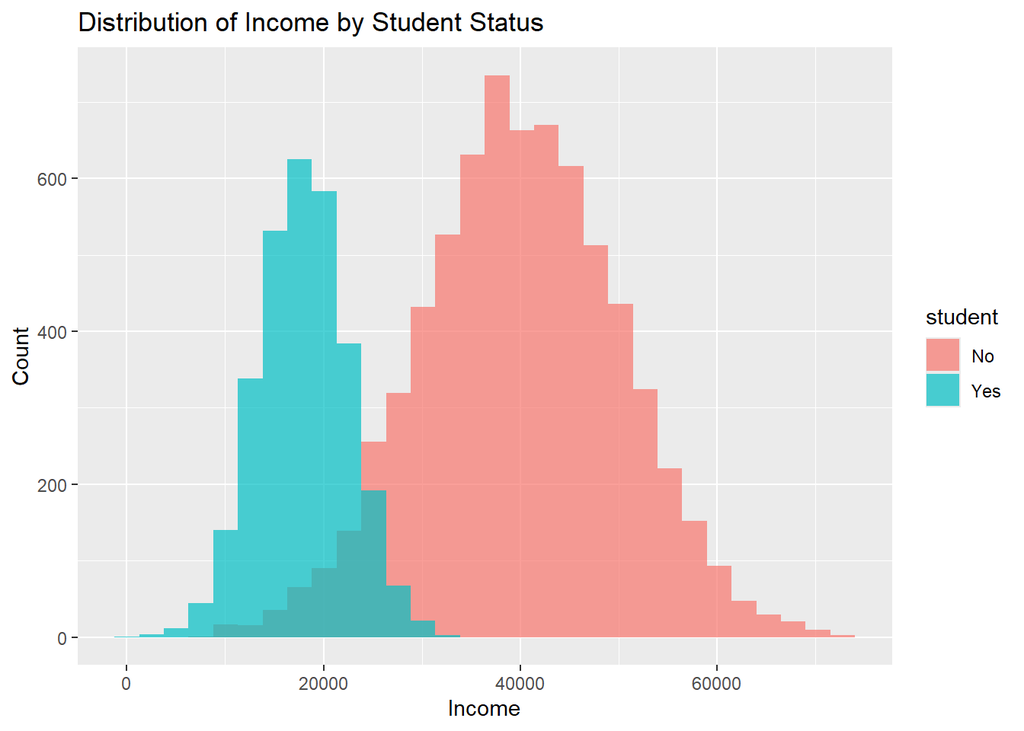

```r
ggplot(data, aes(x=income, fill = student))+
  geom_histogram(bins = 30, alpha = 0.7, position = 'identity')+
  labs(title = "Distribution of Income by Student Status",
       x= "Income",
       y= "Count")
```

This histogram compares income levels between students and non-students regardless of whether they defaulted or not. It helps us examine how income levels vary between students and non-students. Students tend to have lower incomes than non-students, that suggests why student status could be an important predictor when modeling default behavior, especially when considered in combination with income.

### Student Status by Default

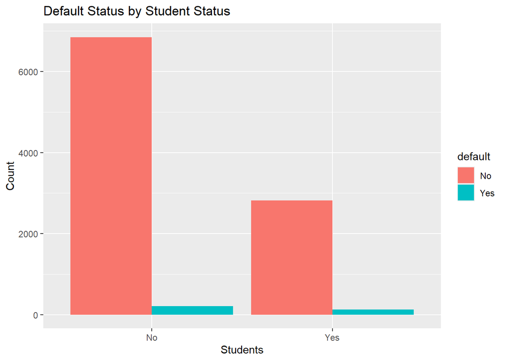

```r
ggplot(data, aes(x=student, fill = default))+
  geom_bar(position = 'dodge')+
  labs(title = "Default Status by Student Status",
       x= "Students",
       y= "Count")
```

A bar chart showing default rates among students and non-students, providing insight into whether student status is associated with higher or lower default risk.

## 4. Logistic Regression

### Fitting the Model

Logistic regression is used for binary classification problems. It estimates the probability that a binary outcome is “Yes” (or 1) based on one or more predictor variables. Here, we use only balance to predict the probability of default.

```r
logit_model = glm(default ~ balance, data=data, family=binomial)
summary(logit_model)
```

```
##
## Call:
## glm(formula = default ~ balance, family = binomial, data = data)
##
## Coefficients:
##               Estimate Std. Error z value Pr(>|z|)
## (Intercept) -1.065e+01  3.612e-01  -29.49   <2e-16 ***
## balance      5.499e-03  2.204e-04   24.95   <2e-16 ***
## ---
## Signif. codes:  0 '***' 0.001 '**' 0.01 '*' 0.05 '.' 0.1 ' ' 1
##
## (Dispersion parameter for binomial family taken to be 1)
##
##     Null deviance: 2920.6  on 9999  degrees of freedom
## Residual deviance: 1596.5  on 9998  degrees of freedom
## AIC: 1600.5
##
## Number of Fisher Scoring iterations: 8
```

The model suggests that as **balance** increases, the **probability of default** also increases. Since the coefficient for balance is positive and statistically significant, individuals with higher balances are more likely to default.

### Predicted Probabilities

```r
data$predicted_prob = predict(logit_model, type="response")
head(data)
```

```
##   default student   balance    income predicted_prob
## 1      No      No  729.5265 44361.625   0.0013056797
## 2      No     Yes  817.1804 12106.135   0.0021125949
## 3      No      No 1073.5492 31767.139   0.0085947405
## 4      No      No  529.2506 35704.494   0.0004344368
## 5      No      No  785.6559 38463.496   0.0017769574
## 6      No     Yes  919.5885  7491.559   0.0037041528
```

We calculate the predicted probabilities of default for each observation. These probabilities range between 0 and 1.

### Evaluate Model Performance

After fitting the logistic regression model, we evaluate its performance by comparing the predicted default labels with the actual values. We use a classification threshold of 0.5, meaning if the predicted probability of default is greater than 0.5, we classify the case as “Yes” (default); otherwise, we classify it as “No” (non-default).We then constructed a confusion matrix.

```r
threshold = 0.5
data$predicted_default = ifelse(data$predicted_prob > threshold, "Yes", "No")
conf_matrix = table(data$predicted_default, data$default)
conf_matrix
```

```
##
##         No  Yes
##   No  9625  233
##   Yes   42  100
```

Interpretation:

```
True Negatives (TN): 9625 individuals were correctly predicted not to default.

True Positives (TP): 100 individuals were correctly predicted to default.

False Positives (FP): 42 individuals were incorrectly predicted to default, but they actually didn’t.

False Negatives (FN): 233 individuals were incorrectly predicted not to default, but they actually did.
```

This gives insight into the types of errors the model is making:

```
It is quite good at identifying non-defaulters (high TN).

It misses a substantial number of defaulters (high FN), which is important if the cost of failing to detect a default is high.
```

### Calculating Accuracy

```r
accuracy = sum(diag(conf_matrix)) / sum(conf_matrix)
accuracy
```

```
## [1] 0.9725
```

the model achieves 97.25% accuracy, but that high number can be misleading in imbalanced datasets like this one (most people don’t default). In such cases, it’s also important to consider:

```
Sensitivity (Recall for "Yes") = TP / (TP + FN) = 100 / (100 + 233) ≈ 0.30

Specificity (Recall for "No") = TN / (TN + FP) = 9625 / (9625 + 42) ≈ 0.996
```

# 5 Multiple Logistic Regression

We now build a more complex logistic regression model by including balance, income, and an **interaction term** between income and student. This allows the model to account for different income effects based on student status.

## 5.1 Fitting the model

Here we will include an **interaction term** between ‘income’ and ‘student’ that will allow the effect of ‘income’ on ‘default’ to differ between ‘student’ and ‘non-student’. The interaction term captures how the relationship between income and default varies for students vs. non-students.

```r
logit_mult_model = glm(default ~ balance + income * student, data=data, family=binomial)
summary(logit_mult_model)
```

```
##
## Call:
## glm(formula = default ~ balance + income * student, family = binomial,
##     data = data)
##
## Coefficients:
##                     Estimate Std. Error z value Pr(>|z|)
## (Intercept)       -1.081e+01  5.031e-01 -21.495   <2e-16 ***
## balance            5.737e-03  2.319e-04  24.736   <2e-16 ***
## income             1.644e-06  8.633e-06   0.190    0.849
## studentYes        -9.343e-01  6.067e-01  -1.540    0.124
## income:studentYes  1.429e-05  2.772e-05   0.516    0.606
## ---
## Signif. codes:  0 '***' 0.001 '**' 0.01 '*' 0.05 '.' 0.1 ' ' 1
##
## (Dispersion parameter for binomial family taken to be 1)
##
##     Null deviance: 2920.6  on 9999  degrees of freedom
## Residual deviance: 1571.3  on 9995  degrees of freedom
## AIC: 1581.3
##
## Number of Fisher Scoring iterations: 8
```

## 5.2 Evaluating the Model

After fitting the multiple logistic regression model, we evaluate its performance by predicting outcomes and comparing them to actual labels. This allows us to assess whether including additional predictors (like income and its interaction with student) improves the model’s performance.

```r
data$mult_predicted_prob = predict(logit_mult_model, type = "response")
data$mult_predicted_default = ifelse(data$mult_predicted_prob > threshold, "Yes", "No")


conf_matrix_mult = table(data$mult_predicted_default, data$default)
conf_matrix_mult
```

```
##
##         No  Yes
##   No  9628  227
##   Yes   39  106
```

This confusion matrix summarizes how well your multiple logistic regression model predicted credit card defaults. It compares the predicted default statuses (“Yes” or “No”) with the actual default statuses in the data.

9628 people were correctly predicted not to default (True Negatives). 227 people actually defaulted but were predicted not to (False Negatives). 39 people were predicted to default but actually did not (False Positives). 106 people were correctly predicted to default (True Positives).

```r
accuracy_mult = sum(diag(conf_matrix_mult)) / sum(conf_matrix_mult)
accuracy_mult
```

```
## [1] 0.9734
```

### Conclusion.

The model is very accurate overall (97.34% accuracy).It is especially good at predicting non-defaulters (high TN count). However, it misses quite a few actual defaulters (227 out of 333), which is important if the goal is to minimize financial risk by identifying likely defaulters.

Accuracy Isn’t Everything. While 97.34% accuracy is great, one should note that the data is imbalanced (many more “No” than “Yes”), therefore the model may be biased toward predicting “No” to maintain high accuracy.That’s why metrics like recall, precision, and F1-score are also important especially when detecting defaulters is critical.

# 6. Multinomial logistic Regression

Multinomial logistic regression is used when the outcome variable has more than two categories. Here, we use the Carseats dataset and classify sales into three categories: Low, Medium, and High.

## 6.1 Load the Data

```r
data2 = Carseats
data2$SalesCategory = cut(data2$Sales, breaks = 3, labels = c("Low", "Medium", "High"))
```

The continuous Sales variable is transformed into a categorical variable for classification.

## 6.2 Fit the Model

We used a multinomial logistic regression model to predict the sales category of car seats; labeled as **“Low”, “Medium”, or “High”**. The model tries to understand how the features **Price**, **Income**, and **Advertising** influence whether a product falls into each of these sales categories.

```r
multi_model = multinom(SalesCategory ~ Price + Income + Advertising, data = data2)
summary(multi_model)
```

```
## Call:
## multinom(formula = SalesCategory ~ Price + Income + Advertising,
##     data = data2)
##
## Coefficients:
##        (Intercept)       Price      Income Advertising
## Medium    3.645096 -0.02909122 0.004288951   0.0834958
## High      4.839031 -0.06414212 0.011164722   0.1417921
##
## Std. Errors:
##        (Intercept)       Price      Income Advertising
## Medium   0.7937487 0.006004112 0.004488935  0.02137942
## High     1.1240727 0.009264365 0.006892574  0.03025054
##
## Residual Deviance: 640.794
## AIC: 656.794
```

The output gives us two sets of results: one for “Medium” sales and another for “High” sales, both compared to the base category “Low”. From the coefficients, we can see that higher prices are associated with a lower chance of being in the “Medium” or “High” sales category. This makes sense as when prices go up, fewer units might be sold. On the other hand, more advertising tends to increase the chances of higher sales, as both “Medium” and “High” sales categories have positive coefficients for the advertising variable. Income has a small positive effect, suggesting that areas with higher income might see slightly better sales, though the effect is relatively small.

The model also provides standard errors, which show how confident we are in the estimates. Smaller values mean more precise estimates.

## 6.3 Make Predictions

```r
data2$nomial_predicted_SalesCat = predict(multi_model)
head(data2)
```

```
##   Sales CompPrice Income Advertising Population Price ShelveLoc Age Education
## 1  9.50       138     73          11        276   120       Bad  42        17
## 2 11.22       111     48          16        260    83      Good  65        10
## 3 10.06       113     35          10        269    80    Medium  59        12
## 4  7.40       117    100           4        466    97    Medium  55        14
## 5  4.15       141     64           3        340   128       Bad  38        13
## 6 10.81       124    113          13        501    72       Bad  78        16
##   Urban  US SalesCategory nomial_predicted_SalesCat
## 1   Yes Yes        Medium                    Medium
## 2   Yes Yes          High                    Medium
## 3   Yes Yes        Medium                    Medium
## 4   Yes Yes        Medium                    Medium
## 5   Yes  No           Low                    Medium
## 6    No Yes        Medium                      High
```

This adds a new column **nomial_predicted_SalesCat** to data2, which contains the predicted sales category (“Low”, “Medium”, or “High”) for each observation, based on the model’s understanding of Price, Income, and Advertising. We can now compare the predicted categories with the actual sales category (data2$SalesCategory) to evaluate the model’s accuracy.

## 6.4 Evaluate Model

We are using a confusion matrix to compare the model’s predictions to the actual sales categories.

```r
conf_matrix_multi = table(data2$nomial_predicted_SalesCat, data2$SalesCategory)
conf_matrix_multi
```

```
##
##          Low Medium High
##   Low     25     17    0
##   Medium  77    224   48
##   High     0      6    3
```

Each row shows the model’s predictions, and each column shows the actual category. Here’s how to read it:

```
25 observations were correctly predicted as "Low".

224 observations were correctly predicted as "Medium".

3 observations were correctly predicted as "High".

However:

    77 actual "Low" cases were predicted as "Medium".

    48 actual "High" cases were predicted as "Medium".

    6 actual "Medium" cases were incorrectly predicted as "High".

    17 actual "Medium" cases were predicted as "Low".
```

This suggests the model tends to favor the “Medium” category, likely because it is the most common in the dataset.It struggles with the “High” category, predicting only 3 of them correctly, while misclassifying many as “Medium”.The “Low” category also has many misclassifications into “Medium”. Overall, while the model shows promise, its performance could be improved for the less frequent categories, possibly by using additional predictors or rebalancing the dataset.

```r
accuracy_multi = sum(diag(conf_matrix_multi)) / sum(conf_matrix_multi)
accuracy_multi
```

```
## [1] 0.63
```

The overall accuracy of the multinomial logistic regression model is 63%, meaning that 63% of the predicted sales categories matched the actual values. While 63% accuracy shows that the model is doing better than random guessing, it also indicates that there is considerable room for improvement — especially in predicting the “Low” and “High” sales categories. This relatively modest accuracy reflects what we observed in the confusion matrix: the model tends to classify most cases as “Medium”, which might be the dominant class in the data. To boost performance, especially for the underrepresented categories, further steps such as feature engineering, class balancing, or trying more advanced classification methods (like random forests or gradient boosting) may be beneficial.

# 7 Assignment Section

## 7.1 Background

Diabetes is a chronic disease affecting millions of individuals worldwide. Early detection through predictive modeling can help guide prevention and treatment. In this assignment, you will use logistic regression to predict whether an individual has diabetes using basic health information.

We will use the Pima Indians Diabetes Dataset, a commonly used dataset in health informatics available from the UCI Machine Learning Repository and built into the mlbench R package.

## 7.2 Simple Logistic Regression

We begin with a simple logistic regression model using a single predictor **glucose level** to determine the probability of diabetes.

### Load Data

```r
# install.packages("mlbench")
library(mlbench)
data("PimaIndiansDiabetes")
df = PimaIndiansDiabetes
```

## 7.3 Data Exploration and Summary Figures

It’s important to understand the structure of the data and explore key variables.

```r
summary(df)
```

```
##     pregnant         glucose         pressure         triceps
##  Min.   : 0.000   Min.   :  0.0   Min.   :  0.00   Min.   : 0.00
##  1st Qu.: 1.000   1st Qu.: 99.0   1st Qu.: 62.00   1st Qu.: 0.00
##  Median : 3.000   Median :117.0   Median : 72.00   Median :23.00
##  Mean   : 3.845   Mean   :120.9   Mean   : 69.11   Mean   :20.54
##  3rd Qu.: 6.000   3rd Qu.:140.2   3rd Qu.: 80.00   3rd Qu.:32.00
##  Max.   :17.000   Max.   :199.0   Max.   :122.00   Max.   :99.00
##     insulin           mass          pedigree           age        diabetes
##  Min.   :  0.0   Min.   : 0.00   Min.   :0.0780   Min.   :21.00   neg:500
##  1st Qu.:  0.0   1st Qu.:27.30   1st Qu.:0.2437   1st Qu.:24.00   pos:268
##  Median : 30.5   Median :32.00   Median :0.3725   Median :29.00
##  Mean   : 79.8   Mean   :31.99   Mean   :0.4719   Mean   :33.24
##  3rd Qu.:127.2   3rd Qu.:36.60   3rd Qu.:0.6262   3rd Qu.:41.00
##  Max.   :846.0   Max.   :67.10   Max.   :2.4200   Max.   :81.00
```

```r
str(df)
```

```
## 'data.frame':    768 obs. of  9 variables:
##  $ pregnant: num  6 1 8 1 0 5 3 10 2 8 ...
##  $ glucose : num  148 85 183 89 137 116 78 115 197 125 ...
##  $ pressure: num  72 66 64 66 40 74 50 0 70 96 ...
##  $ triceps : num  35 29 0 23 35 0 32 0 45 0 ...
##  $ insulin : num  0 0 0 94 168 0 88 0 543 0 ...
##  $ mass    : num  33.6 26.6 23.3 28.1 43.1 25.6 31 35.3 30.5 0 ...
##  $ pedigree: num  0.627 0.351 0.672 0.167 2.288 ...
##  $ age     : num  50 31 32 21 33 30 26 29 53 54 ...
##  $ diabetes: Factor w/ 2 levels "neg","pos": 2 1 2 1 2 1 2 1 2 2 ...
```

The dataset has 768 observations and 9 variables, including:

```
pregnant: number of times pregnant

glucose: plasma glucose concentration

pressure: diastolic blood pressure

triceps: triceps skinfold thickness

insulin: serum insulin level

mass: BMI (body mass index)

pedigree: diabetes pedigree function (genetic likelihood)

age: age in years

diabetes: the target variable (factor with 2 levels: "neg" and "pos")
```

All of the variables are numeric except for the target variable diabetes, which is a factor.

The summary statistics revealed that several variables such as **glucose**, **pressure**, **triceps**, **insulin**, and **mass** contain minimum values of 0, which are not biologically plausible. For example, a glucose level or BMI of 0 is unrealistic in a living person and likely represents missing or incorrectly recorded data. These zeros should be treated as missing values (NA) before proceeding with modeling.

## 7.4 Data Cleaning

### Identify Invalid (Zero) Values

In this dataset, some medical measurements like glucose, pressure, triceps, insulin, and mass should not realistically be zero. We’ll check how many such zero values exist in each of these columns.

```r
sapply(df[, c("glucose", "pressure", "triceps", "insulin", "mass")], function(x) sum(x == 0))
```

```
##  glucose pressure  triceps  insulin     mass
##        5       35      227      374       11
```

### Replace Zeros with NA and check How Many NAs Exist Now

```r
df[, c("glucose", "pressure", "triceps", "insulin", "mass")] <-
  lapply(df[, c("glucose", "pressure", "triceps", "insulin", "mass")],
         function(x) ifelse(x == 0, NA, x))

colSums(is.na(df))
```

```
## pregnant  glucose pressure  triceps  insulin     mass pedigree      age
##        0        5       35      227      374       11        0        0
## diabetes
##        0
```

### Handling Missing (NA) values using Median imputation.

We chose median imputation over mean or mode because it is better suited for the type of data we’re working with. The affected variables; glucose, blood pressure, insulin, and BMI, are all continuous numeric variables. These types of variables often have skewed distributions or extreme outliers (for example, insulin has a maximum value of 846), which can heavily influence the mean. In contrast, the median is more robust to such outliers and provides a more reliable measure of central tendency in these cases. By using median imputation, we preserve the integrity of the dataset without letting extreme values distort our imputed results.

```r
# Define the columns that had zeros turned into NA
vars_to_impute <- c("glucose", "pressure", "triceps", "insulin", "mass")

# Apply median imputation for each column
df[vars_to_impute] <- lapply(df[vars_to_impute], function(x) {
  x[is.na(x)] <- median(x, na.rm = TRUE)
  return(x)
})

# Verify that no missing values remain
colSums(is.na(df))
```

```
## pregnant  glucose pressure  triceps  insulin     mass pedigree      age
##        0        0        0        0        0        0        0        0
## diabetes
##        0
```

## 7.5 Visualizing the Data

### Distribution of Key Health Indicators by Diabetes Status

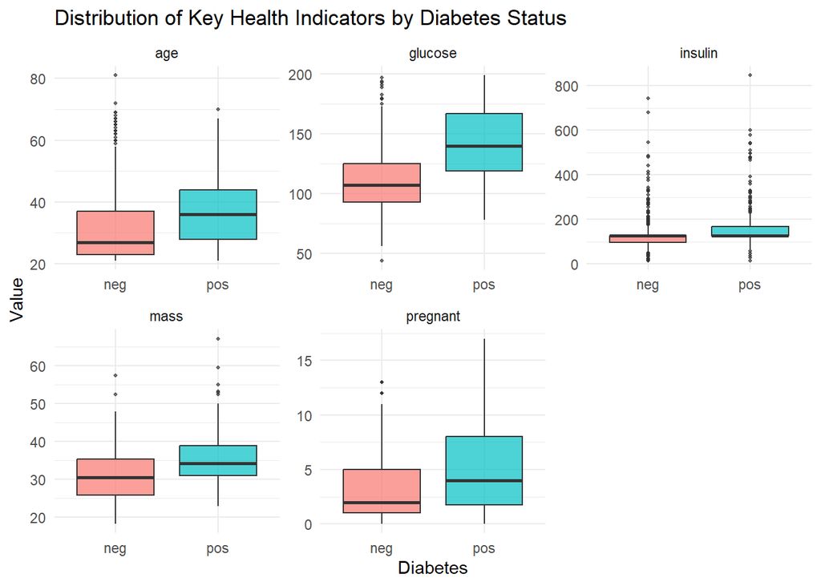

```r
# Select relevant variables and reshape data to long format
boxplot_vars <- df %>%
  select(diabetes, glucose, mass, insulin, age, pregnant) %>%
  pivot_longer(cols = -diabetes, names_to = "Variable", values_to = "Value")

# Create boxplots
ggplot(boxplot_vars, aes(x = diabetes, y = Value, fill = diabetes)) +
  geom_boxplot(alpha = 0.7, outlier.size = 0.8) +
  facet_wrap(~Variable, scales = "free", ncol = 3) +
  labs(title = "Distribution of Key Health Indicators by Diabetes Status",
       x = "Diabetes",
       y = "Value") +
  theme_minimal() +
  theme(legend.position = "none")
```

The boxplots comparing various health indicators by diabetes status reveal how each variable differs between individuals with and without diabetes. **Glucose** stands out with the most noticeable separation as people with diabetes generally have much higher glucose levels, which supports using it as a primary predictor in the Simple Logistic Regression. **BMI (mass)** also shows a moderate difference, with slightly higher values among diabetic individuals. **Insulin** levels display some variation, though with more spread and overlap, suggesting that while informative, it may not be as strong a standalone predictor. **Age** shows a mild difference, with older individuals slightly more represented in the diabetic group. Lastly, the number of times **pregnant** has some separation, though the overlap is quite large. Overall, these visualizations help justify the inclusion of variables like glucose, BMI, insulin, and age in a multiple logistic regression model, as they appear to be associated with diabetes outcomes to varying degrees.

## 7.6 Fit the Model

We split the data into training and testing sets, then fit a logistic regression model using glucose as the sole predictor.

```r
set.seed(123) # for reproducibility

# Add a unique ID to each row
df <- df %>%
  mutate(id = row_number())

# Sample 70% of the data for training
train <- df %>%
  sample_frac(0.7)

# Use anti_join to get the remaining 30% for testing
test <- anti_join(df, train, by = "id")

# Fit using glucose as a predictors of diabetes
simple_model <- glm(diabetes ~ glucose, data = train, family = binomial)
summary(simple_model)
```

```
##
## Call:
## glm(formula = diabetes ~ glucose, family = binomial, data = train)
##
## Coefficients:
##              Estimate Std. Error z value Pr(>|z|)
## (Intercept) -6.024428   0.547952  -10.99   <2e-16 ***
## glucose      0.042780   0.004211   10.16   <2e-16 ***
## ---
## Signif. codes:  0 '***' 0.001 '**' 0.01 '*' 0.05 '.' 0.1 ' ' 1
##
## (Dispersion parameter for binomial family taken to be 1)
##
##     Null deviance: 695.03  on 537  degrees of freedom
## Residual deviance: 547.62  on 536  degrees of freedom
## AIC: 551.62
##
## Number of Fisher Scoring iterations: 4
```

### Interpret Coefficients

The logistic regression model shows that glucose is a strong and significant predictor of diabetes. The coefficient for glucose is 0.0428, which means that as a person’s glucose level increases by 1 unit, their odds of having diabetes increase by about 4.4%. This is based on the odds ratio, which is calculated as the exponential of the coefficient. The very small p-value (less than 0.001) indicates that this relationship is statistically significant and unlikely to be due to chance. Overall, the model confirms that higher glucose levels are strongly associated with a greater likelihood of having diabetes.

### Prediction on Test Data

```r
# Predict probabilities of having diabetes in the test set
test$predicted_prob <- predict(simple_model, newdata = test, type = "response")

# Classify outcomes based on a 0.5 threshold
test$predicted_class <- ifelse(test$predicted_prob > 0.5, "pos", "neg")

# Generate confusion matrix
conf_matrix <- table(Predicted = test$predicted_class, Actual = test$diabetes)
conf_matrix
```

```
##          Actual
## Predicted neg pos
##       neg 130  44
##       pos  19  37
```

```r
# Calculate overall accuracy
accuracy <- mean(test$predicted_class == test$diabetes)
accuracy
```

```
## [1] 0.726087
```

### Interpret

The model’s predictions were compared to the actual outcomes using a confusion matrix. It correctly identified 130 non-diabetic cases and 37 diabetic cases. However, it also misclassified 44 diabetic individuals as non-diabetic (false negatives) and 19 non-diabetic individuals as diabetic (false positives). The overall accuracy of the model was approximately 72.6%, meaning that about 73 out of every 100 predictions were correct. While this shows that the model performs reasonably well, it also highlights that it misses a fair number of true diabetic cases, which could be important in a real-world healthcare setting. This suggests that while glucose alone is a useful predictor, adding more variables may improve the model’s performance.

## 7.7 Multiple Logistic Regression

```r
# Fit multiple logistic regression model
multi_model <- glm(diabetes ~ glucose + age + mass + pregnant, data = train, family = binomial)

# View model summary
summary(multi_model)
```

```
##
## Call:
## glm(formula = diabetes ~ glucose + age + mass + pregnant, family = binomial,
##     data = train)
##
## Coefficients:
##              Estimate Std. Error z value Pr(>|z|)
## (Intercept) -9.337877   0.855689 -10.913  < 2e-16 ***
## glucose      0.037085   0.004348   8.529  < 2e-16 ***
## age          0.013450   0.010946   1.229  0.21916
## mass         0.096034   0.017890   5.368 7.96e-08 ***
## pregnant     0.097859   0.037821   2.587  0.00967 **
## ---
## Signif. codes:  0 '***' 0.001 '**' 0.01 '*' 0.05 '.' 0.1 ' ' 1
##
## (Dispersion parameter for binomial family taken to be 1)
##
##     Null deviance: 695.03  on 537  degrees of freedom
## Residual deviance: 501.71  on 533  degrees of freedom
## AIC: 511.71
##
## Number of Fisher Scoring iterations: 5
```

### Prediction on Test Data

```r
# Predict on test set
test$multi_pred_prob <- predict(multi_model, newdata = test, type = "response")
test$multi_pred_class <- ifelse(test$multi_pred_prob > 0.5, "pos", "neg")

# Confusion matrix
table(Predicted = test$multi_pred_class, Actual = test$diabetes)
```

```
##          Actual
## Predicted neg pos
##       neg 131  35
##       pos  18  46
```

```r
# Accuracy
mean(test$multi_pred_class == test$diabetes)
```

```
## [1] 0.7695652
```

### Interpret

The model achieved an accuracy of approximately 76.96%, meaning it correctly predicted diabetes status for about 77% of the individuals. The confusion matrix shows that the model correctly identified 131 non-diabetic (true negatives) and 46 diabetic (true positives) cases. However, it misclassified 35 diabetic individuals as non-diabetic (false negatives) and 18 non-diabetics as diabetic (false positives). Compared to the simple model, which only used glucose, this model shows a slight improvement in accuracy. More importantly, it correctly identifies more diabetic cases, suggesting that including additional predictors like age, BMI, and pregnancy count improves the model’s ability to detect diabetes.

## 7.8 K-Nearest Neighbors Classification

K-Nearest Neighbors (KNN) is a simple, flexible algorithm that makes predictions based on the majority class of the closest data points.

We select four numeric health indicators; **glucose, age, BMI (mass), and number of pregnancies** and standardized them using the scale() function, since KNN is sensitive to differences in scale.

```r
library(class)
# Step 1: Select and scale the predictors manually
train_knn <- as.data.frame(scale(train[, c("glucose", "age", "mass", "pregnant")]))
test_knn  <- as.data.frame(scale(test[, c("glucose", "age", "mass", "pregnant")]))

# Step 2: Set the class labels
train_labels <- train$diabetes
test_labels  <- test$diabetes
```

### Fit the Model

We create the training and testing sets and extract the true class labels for each. The model was fit using k = 5, meaning it looked at the 5 nearest neighbors to make each prediction.

```r
# Fit KNN (e.g., k = 5)
knn_pred <- knn(train = train_knn, test = test_knn, cl = train_labels, k = 5)
```

### Applying the Model to Test Data

```r
# Confusion matrix
table(Predicted = knn_pred, Actual = test_labels)
```

```
##          Actual
## Predicted neg pos
##       neg 125  29
##       pos  24  52
```

```r
# Accuracy
mean(knn_pred == test_labels)
```

```
## [1] 0.7695652
```